# Comparação de Dois Grupos

## Objetivo

Apresentar algumas estratégias para comparação de grupos em situações fora do habitual.

O que será coberto :

- Técnicas descritivas e Inferenciais com a Função de Deslocamento;
- Técnicas Inferenciais sobre percentis baseadas em bootstrap.

## Função de Deslocamento

## Habitualmente…

Habitualmente, comparamos dois grupos (tratamento e controle) por medidas de locação e/ou escala para encontrar um vencedor sobre as métricas estabelecidas. Um exemplo é o modelo ANOVA,

\[ y_{ij} = \mu + \alpha_i + \epsilon_{ij} \\ \epsilon_{ij} \sim N(0,\sigma^2) \] que utiliza médias. Entretanto, nem sempre essas hipóteses são razoáveis.

Exemplo ?

## Assim

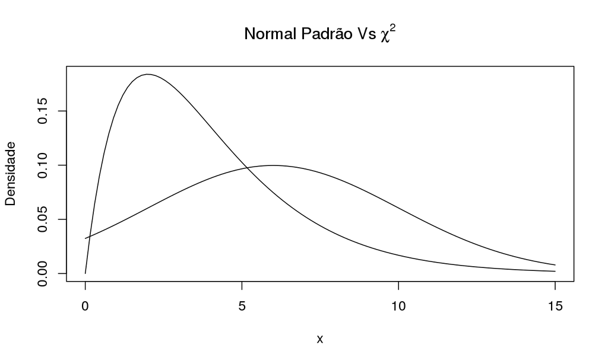

Visivelmente, não há um claro vencedor absoluto. E agora ?

## Solução

Compare os grupos com a Função de Deslocamento (Shift Function).

**Definição:** *Sejam \(y_q\) e \(x_q\) os quantis dos grupos de tratamento e controle, respectivamente .A Função de Deslocamento \(\Delta(x_q)\) é definida como \(\Delta(x_q) = y_q - x_q\)*

**Interpretação:** A Função de Deslocamento \(\Delta(x_q)\) mede quanto o grupo controle deve deslocado de forma a ser comparável ao grupo experimental, para um q-ésimo quantil.

## Coisas boas sobre ela

- Utiliza quantis;
- Intuitiva;
- Não assume distribuição;
- Pode inclusive ser utilizada quando os grupos são dependentes;
- Gráficos !! (grafique \(x_q\) VS \(\Delta(x_q)\))

## Inferência

Será dada na forma de Intervalos de Confianças *simultâneas*. São de dois tipos:

- Baseados no distâncias de Kolmogorov;
  - Sband (distância usual);
  - Wband (distância ponderada);
- Baseados somente nos decis.

## Banda-S e Banda-W

Como são baseadas nas distâncias \(d_K(x)=|\hat{F}(x) - \hat{G}(x)|\) de Kolmogorov, as bandas herdam as características de \(d_K(x)\). Logo, é importante levar em consideração que

- A banda-S tende a ser mais (menos) sensível à diferenças no que ocorrem ao redor do centro (cauda) das distribuições do que a banda-W;
- A banda-S forma intervalos assintóticamente mais largos e menos estáveis que a banda-W;
- A banda-W fornece resultados exatos.

## Exemplo

Dados para medir impacto do ozônio no ganho de peso em ratos. À esquerda está a banda-S e, à direita, a banda-W

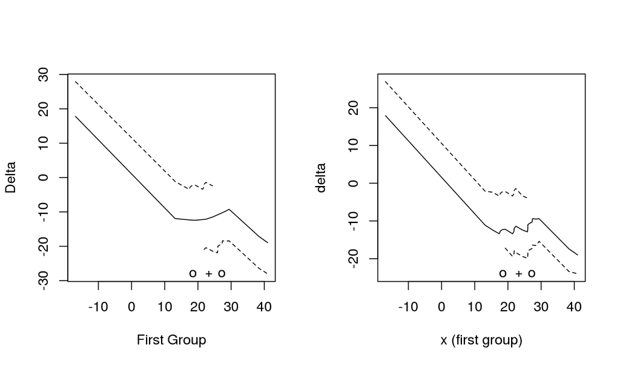

## Exemplo

A figura abaixo mostra o intervalo criado para os decis somente.

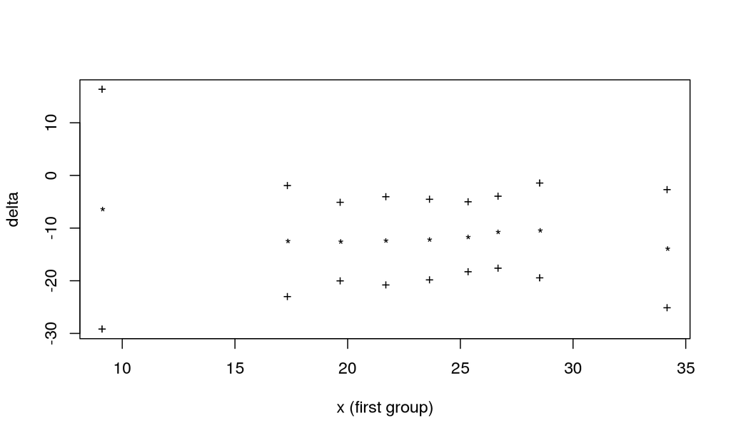